• Previous model for counterfactual times can be expressed more generally as

𝑈

=

∫

exp 𝜓 ∗ 𝑒

𝑑𝑡

• Model above describes the mean survival time modeled by an accelerated failure time

(AFT) model

• More general relationships can be explored by changing the expression inside the integral

• Ex: Balance 𝑈

over multiple visits, include covariates, more flexible model

Survival

time

Indicator of

treatment at

time 𝑡

“Sum”

over time

[figure not shown]

RPSFT Sources

Ouwens M, Hauch O, Franzén S. A Validation Study of the Rank-Preserving Structural Failure Time Model: Confidence Intervals and Unique, Multiple,

and Erroneous Solutions. Medical Decision Making. 2018;38(4):509-519

Bennett, Iain, et al. "Accounting for uncertainty in decision analytic models using rank preserving structural failure time modeling: application to parametric

survival models." Value in Health 21.1 (2018): 105-109.

Sullivan, Thomas R., et al. "Adjusting for Treatment Switching in Oncology Trials: A Systematic Review and Recommendations for

Reporting." Value in Health 23.3 (2020): 388-396.

Y. -K. Tu and D.C. Greenwood, Modern Methods for Epidemiology, Springer 2012, Chapter 14 https://people.maths.bris.ac.uk/~maxvd/Tilling_gEstim.pdf

Complicated original papers:

Robins, James. "A new approach to causal inference in mortality studies with a sustained exposure period—application to control of the healthy worker

survivor effect." Mathematical modelling 7.9-12 (1986): 1393-1512.

Robins, James. "Estimation of the time-dependent accelerated failure time model in the presence of confounding factors." Biometrika 79.2 (1992): 321-

334.

Robins, James M. "Correcting for non-compliance in randomized trials using structural nested mean models." Communications in Statistics-Theory and

methods 23.8 (1994): 2379-2412.

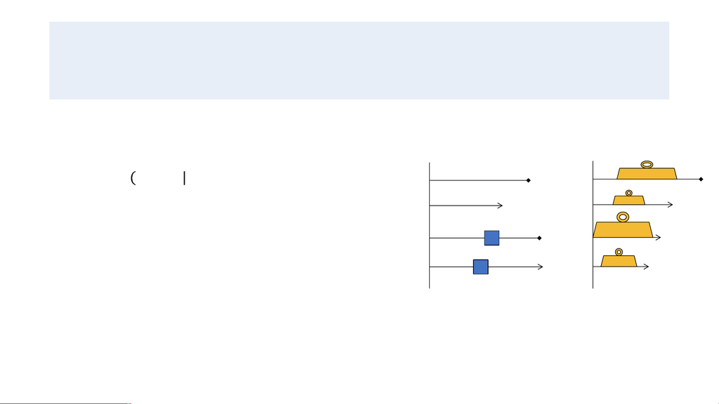

Inverse Probability of Censoring Weights (IPCW)

regression or Cox regression

• Re-weigh the patient to mimic patient

population as if no one switched (remove

selection bias)

• High weight if Pr(Switch | Covariates) close to 1

• Low weight if Pr(Switch | Covariates) close to 0

S

S

Observed (ITT) control arm

Non

switchers

Switchers

IPC weighted

WEIGHT

WEIGHT

WEIGHT

WEIGHT

[figure not shown]

IPCW Assumptions

1. Are there unmeasured factors that influence a patients likelihood to switch

and their survival time?

2. Have too many patients switched to accurately model Pr(Switch)?

• If 95% of your patients switch, it may be difficult to say what factors influence

switching

• >80% seems to be tipping point

[figure not shown]

IPCW Sources

• Sullivan, Thomas R., et al. "Adjusting for Treatment Switching in Oncology Trials: A

Systematic Review and Recommendations for Reporting." Value in Health 23.3 (2020):

388-396.

• Latimer, Nicholas R., and Keith R. Abrams. "NICE DSU Technical Support Document 16:

Adjusting survival time estimates in the presence of treatment switching." (2014): 18.

[figure not shown]

More Methods

• Many methods for adjusting survival times for crossover come from

causal inference

• Methods presented are special cases of structural nested failure time

models (SNFTM) and g-estimation.

• Very complicated, technical literature.

• More complicated or tailored methods will probably come from these

topics.

[figure not shown]

Sources

Structural nested failure time models (SNFTM)

Lok, Judith, et al. "Estimating the causal effect of a time-varying treatment on time-to-event using structural

nested failure time models." Statistica Neerlandica 58.3 (2004): 271-295

G-estimation / G-computation

Wiley StatsRef: Statistics Reference Online, G-Computation Formula, Daniel, Rhian,

https://statnav.files.wordpress.com/2017/10/g-computation-formula-preprint.pdf

Sterne, Jonathan AC, and Kate Tilling. "G-estimation of causal effects, allowing for time-varying

confounding." The Stata Journal 2.2 (2002): 164-182.

Keil AP, Edwards JK, Richardson DB, Naimi AI, Cole SR. The parametric g-formula for time-to-event data:

intuition and a worked example. Epidemiology. 2014;25(6):889-897.

Y. -K. Tu and D.C. Greenwood, Modern Methods for Epidemiology, Springer 2012, Chapter 14

https://people.maths.bris.ac.uk/~maxvd/Tilling_gEstim.pdf